# Box office Revenue Predictions using Random Forest

Emad Abdellatif

May 23, 2024

# Introduction

1. Exploratory data analysis,
2. Feature engineering,
3. Treating missing values, and
4. Machine learning using random forest.

```r
library(tidyverse) # Multiple packages
library(plotly) # Interactive visualizations
library(ggthemes) # Visualization themes
library(viridis) # Color scales
library(corrplot) # Correlation visualizations
library(gridExtra) # Grids for visualizations
library(VIM) # Visualizing missing values
library(lubridate) # Working with dates
library(randomForest) # Classification algorithm
```

Read in the train and test data sets and then bind the two sets using `bind_rows()` from the DPLYR package. We will do all feature engineering and data preparation on both data sets and then divide our data into train and test sets again later before creating our model.

```r
setwd("C:/Users/Emad Abdellatif/Desktop/Data Science Projects/Movies-Box-Office")
train_data = read.csv('train.csv', na.strings=c("", '#N/A', '[]', '0'))
test_data = read.csv('test.csv', na.strings=c("", '#N/A', '[]', '0'))

full_data  <- bind_rows(train_data, test_data)
```

Lets explore our data and see how it looks like.

```r
glimpse(full_data)
```

```
## Rows: 7,398
## Columns: 23
## $ id                    <int> 1, 2, 3, 4, 5, 6, 7, 8, 9, 10, 11, 12, 13, 14, 1…
## $ belongs_to_collection <chr> "[{'id': 313576, 'name': 'Hot Tub Time Machine C…
## $ budget                <int> 14000000, 40000000, 3300000, 1200000, NA, 800000…
## $ genres                <chr> "[{'id': 35, 'name': 'Comedy'}]", "[{'id': 35, '…
## $ homepage              <chr> NA, NA, "http://sonyclassics.com/whiplash/", "ht…
## $ imdb_id               <chr> "tt2637294", "tt0368933", "tt2582802", "tt182148…
## $ original_language     <chr> "en", "en", "en", "hi", "ko", "en", "en", "en", …
## $ original_title        <chr> "Hot Tub Time Machine 2", "The Princess Diaries …
## $ overview              <chr> "When Lou, who has become the \"father of the In…
## $ popularity            <dbl> 6.575393, 8.248895, 64.299990, 3.174936, 1.14807…
## $ poster_path           <chr> "/tQtWuwvMf0hCc2QR2tkolwl7c3c.jpg", "/w9Z7A0GHEh…
## $ production_companies  <chr> "[{'name': 'Paramount Pictures', 'id': 4}, {'nam…
## $ production_countries  <chr> "[{'iso_3166_1': 'US', 'name': 'United States of…
## $ release_date          <chr> "2/20/15", "8/6/04", "10/10/14", "3/9/12", "2/5/…
## $ runtime               <int> 93, 113, 105, 122, 118, 83, 92, 84, 100, 91, 119…
## $ spoken_languages      <chr> "[{'iso_639_1': 'en', 'name': 'English'}]", "[{'…
## $ status                <chr> "Released", "Released", "Released", "Released", …
## $ tagline               <chr> "The Laws of Space and Time are About to be Viol…
## $ title                 <chr> "Hot Tub Time Machine 2", "The Princess Diaries …
## $ Keywords              <chr> "[{'id': 4379, 'name': 'time travel'}, {'id': 96…
## $ cast                  <chr> "[{'cast_id': 4, 'character': 'Lou', 'credit_id'…
## $ crew                  <chr> "[{'credit_id': '59ac067c92514107af02c8c8', 'dep…
## $ revenue               <int> 12314651, 95149435, 13092000, 16000000, 3923970,…
```

With a quick observation, it looks like there are a few variables that could use some cleaning up. Because of this, we will use *regular expressions* and extract the appropriate information from them before using them in our model.

# Exploratory Data Analysis

Lets begin by plotting our existing variables `budget`, `runtime`, and `popularity` in order to see their relation to the variable we are trying to predict, revenue.

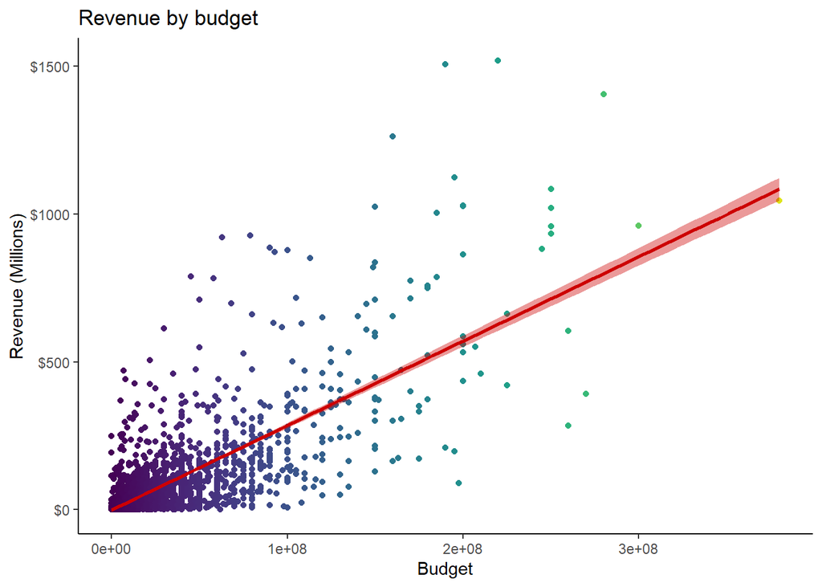

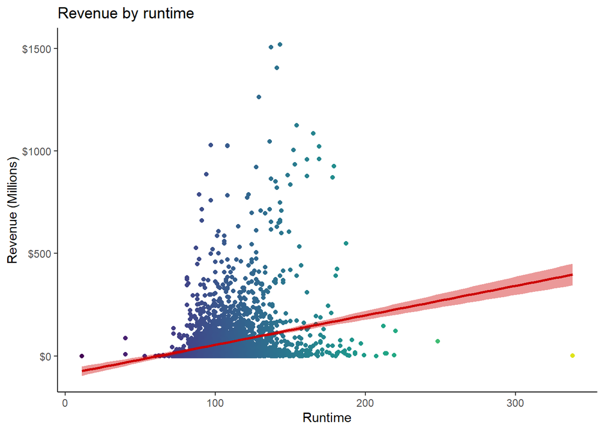

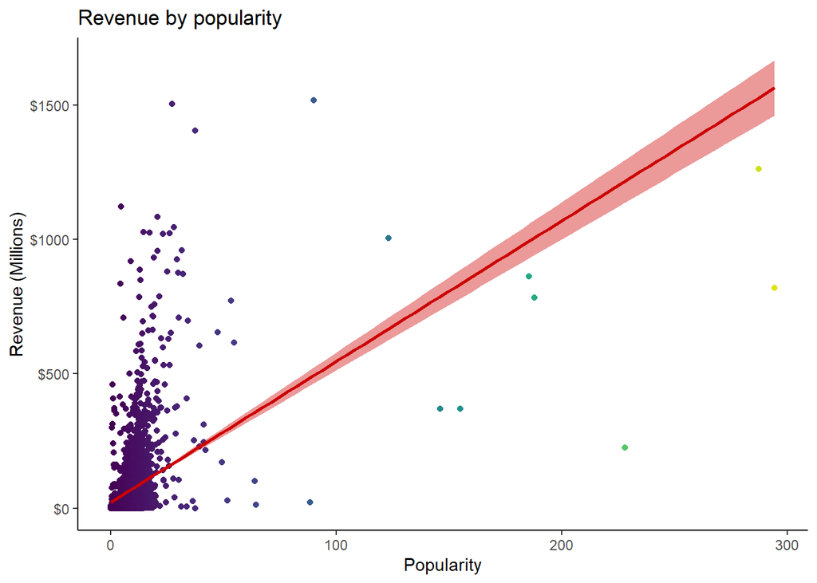

We can see some clear trends that an increase in budget and popularity tend to lead to higher revenue. Runtime seems to show this trend as well, although not as strongly.

# Feature Engineering

## Collection

The strings in `belongs_to_collection` are messy and contain information we do not need. Lets use regular expressions to extract the collection names from these strings.

```r
full_data$collection_name <- str_extract(full_data$belongs_to_collection,
            pattern = "(?<=name\\'\\:\\s{1}\\').+(?=\\'\\,\\s{1}\\'poster)")
```

Now that we have extracted the collection names lets check the biggest collections.

```r
full_data[1:3000,] %>%
   group_by(collection_name) %>%
   summarise(movie_count = n()) %>%
   arrange(desc(movie_count)) %>%
   filter(!is.na(collection_name)) %>%
   head(10)
```

```
## # A tibble: 10 × 2
##    collection_name                        movie_count
##    <chr>                                        <int>
##  1 James Bond Collection                           16
##  2 Friday the 13th Collection                       7
##  3 The Pink Panther (Original) Collection           6
##  4 Pokémon Collection                               5
##  5 Police Academy Collection                        5
##  6 Alien Collection                                 4
##  7 Ice Age Collection                               4
##  8 Paranormal Activity Collection                   4
##  9 Rambo Collection                                 4
## 10 Resident Evil Collection                         4
```

As each collection is fairly small we will engineer a new variable that consist of either being in a collection or not being in a collection.

```r
full_data$collection[!is.na(full_data$belongs_to_collection)] <- 'Collection'
full_data$collection[is.na(full_data$belongs_to_collection)] <- 'No collection'
```

Now lets plot our new variable to visualize how the two levels differ on revenue.

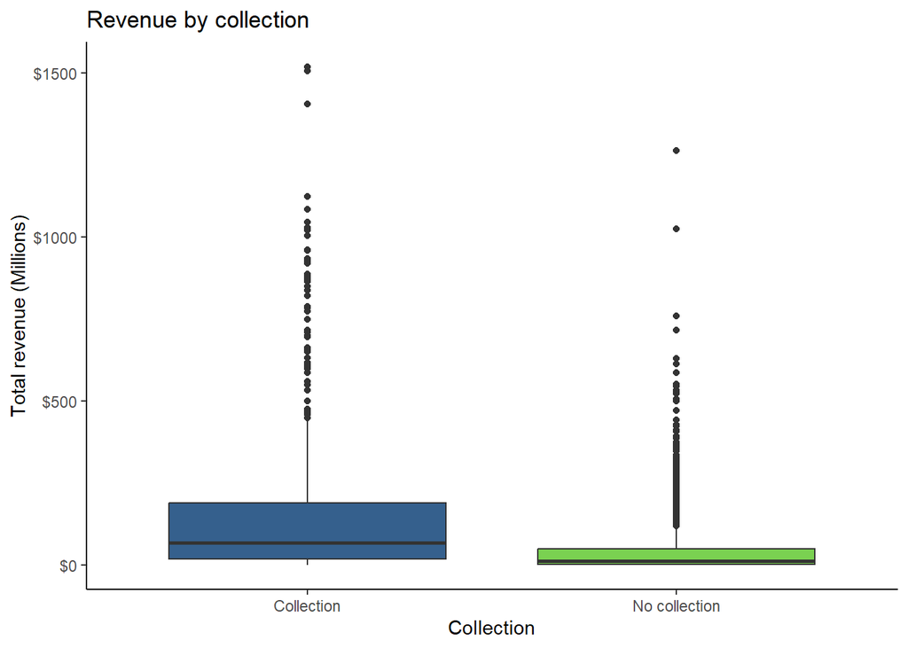

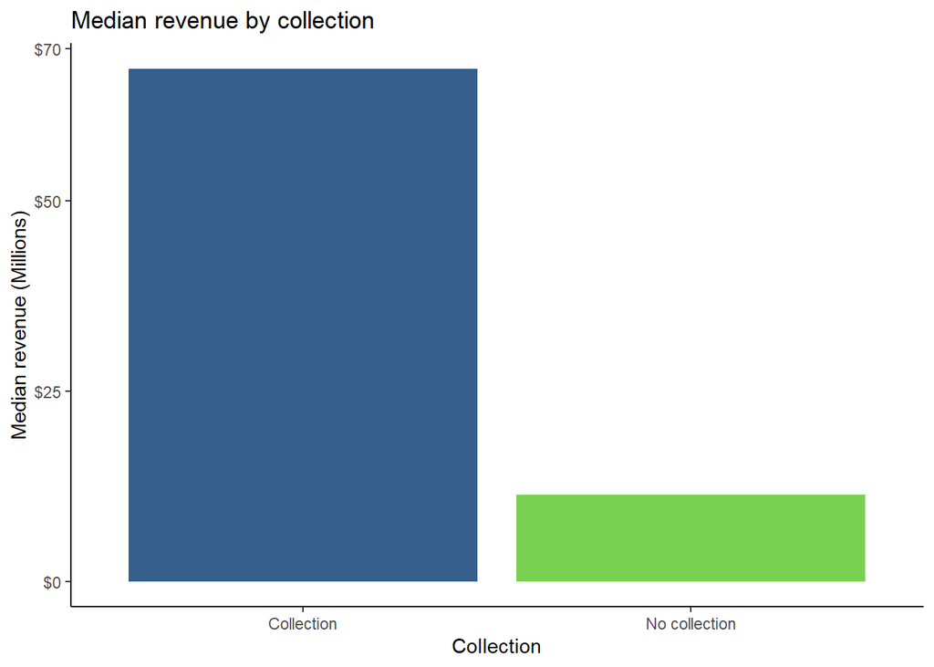

On average, movies that are in collections seem to be getting higher revenues as we can see by looking at the box plot and bar plot.

## Main genre

We now want to extract the first genre from the `genres` strings to get the main genre for each movie. First, we will create a vector with the genres we want to extract. Next, we will extract the genres and add them to a new variable called `main_genre.`

```r
genres_matching_point <- "Comedy|Horror|Action|Drama|Documentary|Science Fiction|
              Crime|Fantasy|Thriller|Animation|Adventure|Mystery|War|Romance|Music|
              Family|Western|History|TV Movie|Foreign"

full_data$main_genre <- str_extract(full_data$genres, genres_matching_point)
```

Lets plot `main_genre` to find (1) how many movies there are per genre and (2) the median revenue by genre.

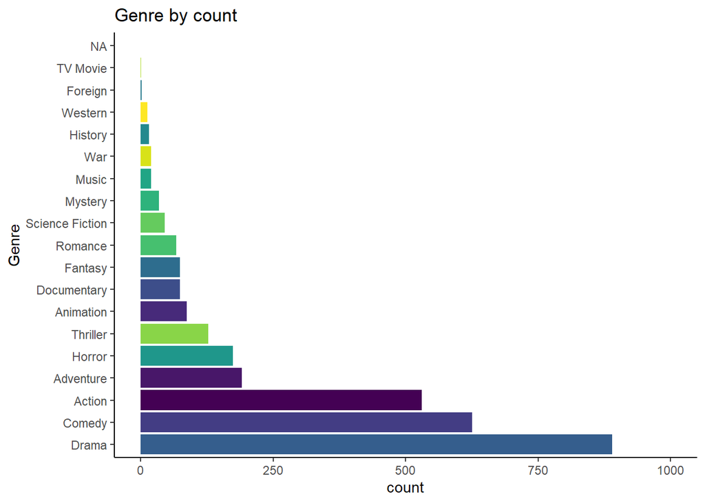

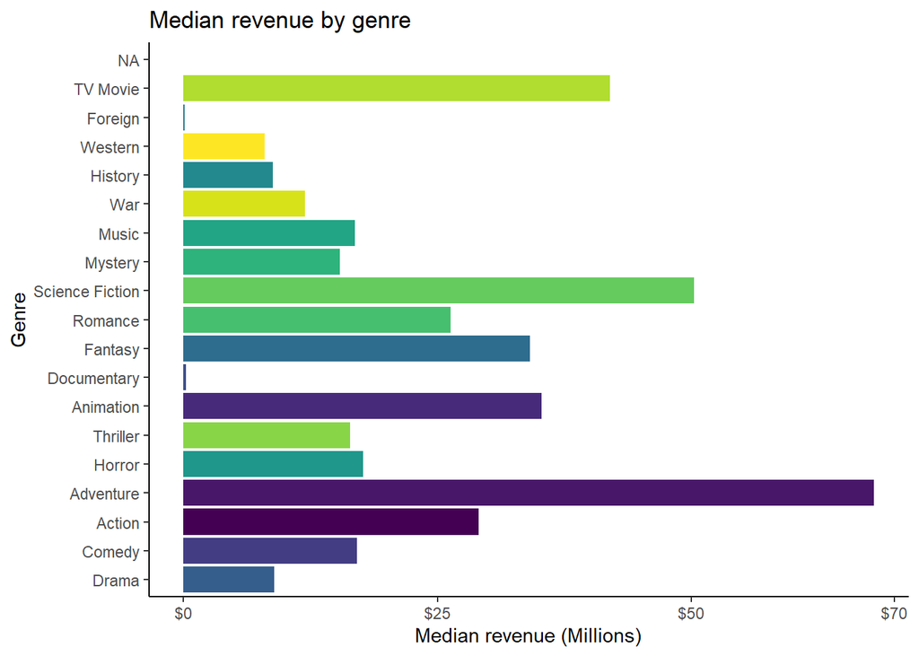

## Production company id

We want to extract the first (and main) production company id from `production_companies` and create the new variable `prod_comp_id.`

```r
full_data$prod_comp_id <- str_extract(full_data$production_companies,
                                      pattern = "([0-9]+)")
```

Lets plot how this variable and see how it affects revenue.

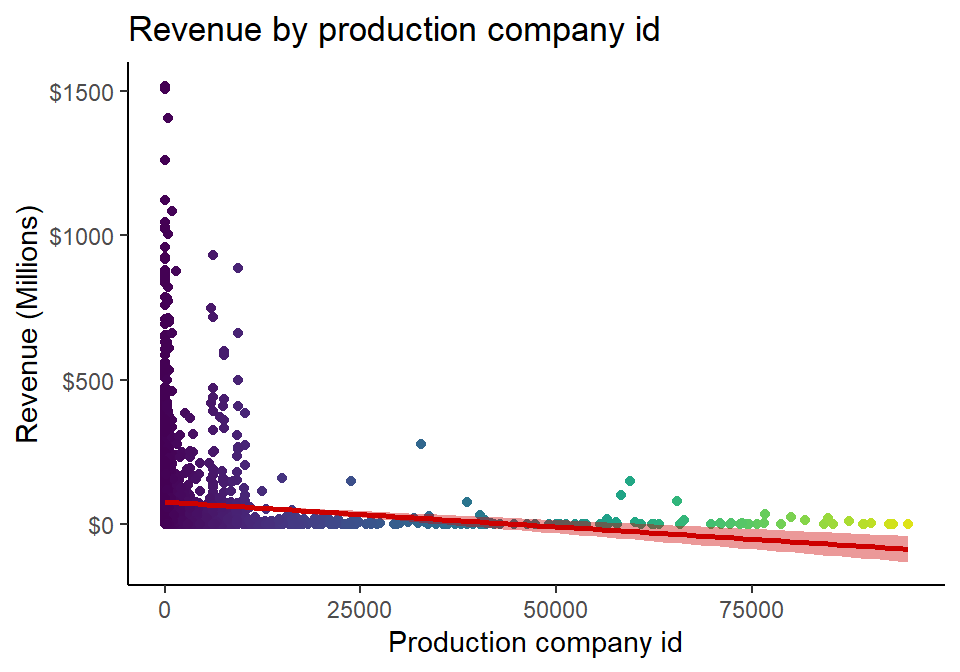

Production companies with lower numbered id’s seem to be making more revenue compared to the ones with higher id’s. Lets check the correlation to confirm this.

```r
cor(full_data$revenue, full_data$prod_comp_id, use = 'complete.obs')
```

```
## [1] -0.1282278
```

There seems to be a *small* negative correlation present.

## Top production companies

Lets extract the main production company name from `production_companies`.

```r
full_data$prod_comp_name <- gsub('(^\\[\\{\'name\'\\:\\s\'|\'\\,\\s\'id.*)', '',
                                 full_data$production_companies)
```

Check the top production companies ordered by number of movies produced.

```r
full_data[1:3000,] %>%
   group_by(prod_comp_name) %>%
   summarise(movie_count = n()) %>%
   arrange(desc(movie_count)) %>%
   filter(!is.na(prod_comp_name)) %>%
   head(10)
```

```
## # A tibble: 10 × 2
##    prod_comp_name                         movie_count
##    <chr>                                        <int>
##  1 Universal Pictures                             167
##  2 Paramount Pictures                             158
##  3 Twentieth Century Fox Film Corporation         122
##  4 Columbia Pictures                               90
##  5 Warner Bros.                                    70
##  6 New Line Cinema                                 69
##  7 Walt Disney Pictures                            62
##  8 Columbia Pictures Corporation                   44
##  9 TriStar Pictures                                44
## 10 United Artists                                  41
```

We will create a new variable called `top_prod_comp` (top production companies). We will create a separate category for each production company that has produced at least 60 movies that are present in our data set. All other production companies, including NAs, get put into an ‘other’ category.

```r
full_data$top_prod_comp[full_data$prod_comp_name=='Universal Pictures'] <- 'Universal Pictures'
full_data$top_prod_comp[full_data$prod_comp_name=='Paramount Pictures'] <- 'Paramount Pictures'
full_data$top_prod_comp[full_data$prod_comp_name=='Twentieth Century Fox Film Corporation'] <- 'Twentieth Century Fox Film Corporation'
full_data$top_prod_comp[full_data$prod_comp_name=='Columbia Pictures'] <- 'Columbia Pictures'
full_data$top_prod_comp[full_data$prod_comp_name=='New Line Cinema'] <- 'New Line Cinema'
full_data$top_prod_comp[full_data$prod_comp_name=='Warner Bros.'] <- 'Warner Bros.'
full_data$top_prod_comp[full_data$prod_comp_name=='Walt Disney Pictures'] <- 'Walt Disney Pictures'

full_data$top_prod_comp[is.na(full_data$top_prod_comp)] <- 'Other'
```

Lets take a look at the effects of this variable on revenue.

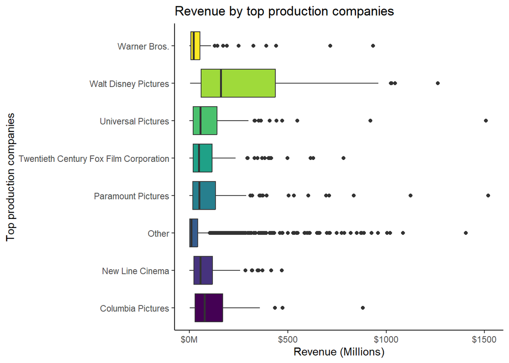

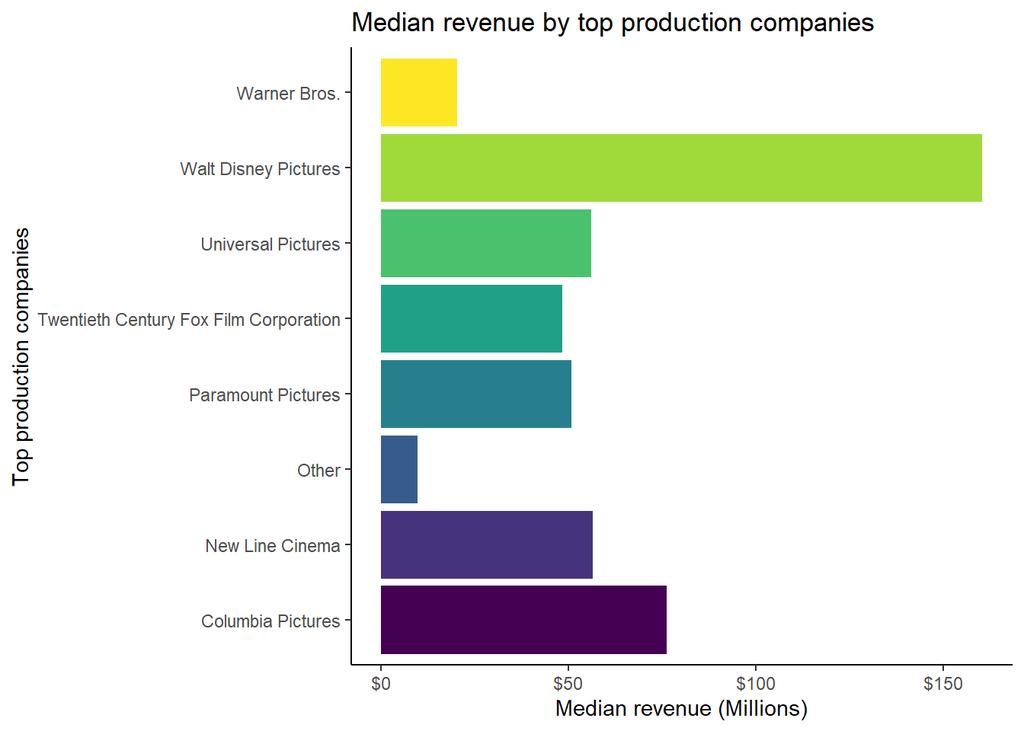

Here we can see that the average revenue for a lot of the top production companies is higher than the ‘other’ production companies.

## Production company size

Now, lets move on to create `prod_comp_size` (production company size – *big producer* v. *small producer*). We will assign the production companies that have at least 60 movies each as big producers and all the rest as small producers. We will assume that all NAs are small producers.

```r
full_data$prod_comp_size[full_data$prod_comp_name=='Universal Pictures'] <- 'Big producer'
full_data$prod_comp_size[full_data$prod_comp_name=='Paramount Pictures'] <- 'Big producer'
full_data$prod_comp_size[full_data$prod_comp_name=='Twentieth Century Fox Film Corporation'] <- 'Big producer'
full_data$prod_comp_size[full_data$prod_comp_name=='Columbia Pictures'] <- 'Big producer'
full_data$prod_comp_size[full_data$prod_comp_name=='New Line Cinema'] <- 'Big producer'
full_data$prod_comp_size[full_data$prod_comp_name=='Warner Bros.'] <- 'Big producer'
full_data$prod_comp_size[full_data$prod_comp_name=='Walt Disney Pictures'] <- 'Big producer'

full_data$prod_comp_size[is.na(full_data$prod_comp_size)] <- 'Small producer'
```

Lets see how our new variable affects revenue.

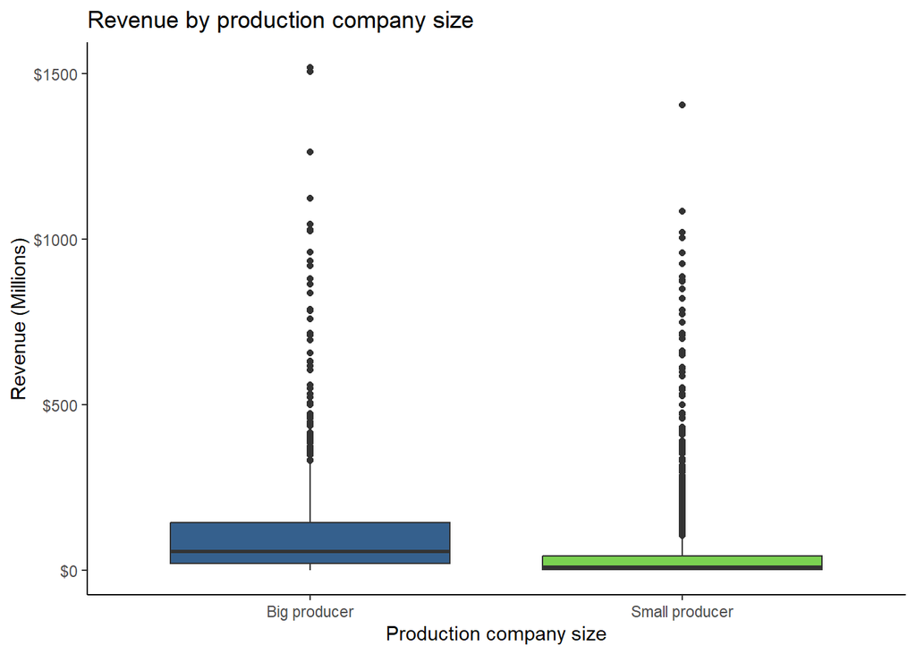

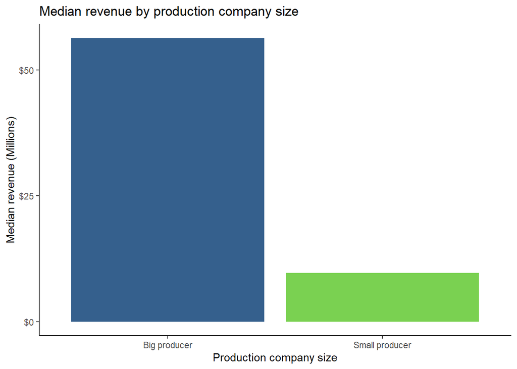

Again, we can see that the big production companies are, on average, making more than the smaller production companies.

## Top production countries

Lets extract the country abbreviations from the messy strings in `production_countries`.

```r
full_data$prod_country <- str_extract(string = full_data$production_countries,
                                      pattern = "[:upper:]+")
```

Check the top countries by number of movies produced.

```r
full_data[1:3000,] %>%
   group_by(prod_country) %>%
   summarise(movie_count = n()) %>%
   arrange(desc(movie_count)) %>%
   filter(!is.na(prod_country)) %>%
   head(10)
```

```
## # A tibble: 10 × 2
##    prod_country movie_count
##    <chr>              <int>
##  1 US                  1818
##  2 GB                   234
##  3 FR                   147
##  4 CA                    97
##  5 DE                    90
##  6 IN                    78
##  7 AU                    52
##  8 JP                    50
##  9 RU                    47
## 10 IT                    36
```

Separate into top production countries (criteria: 100+ movies) and ‘other’.

```r
full_data$top_prod_country[full_data$prod_country=='US'] <- 'United States'
full_data$top_prod_country[full_data$prod_country=='GB'] <- 'Great Britain'
full_data$top_prod_country[full_data$prod_country=='FR'] <- 'France'

full_data$top_prod_country[is.na(full_data$top_prod_country)] <- 'Other'
```

Plot our new `top_prod_country` variable.

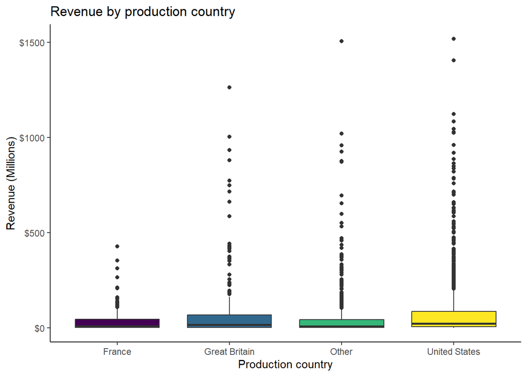

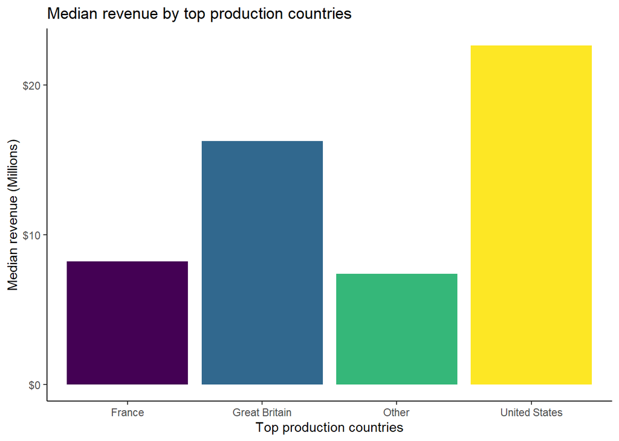

The U.S. and Great Britain seem to, on average, be getting more revenue than the countries that are not among the top production countries.

## IMDB id

We will now extract the IMDb number from the `IMDb_id` string in order to see if this variable affects revenue. There will likely not be any correlation with this and revenue, but we will plot and explore this to make sure.

```r
full_data$imdb_id_2 <- str_extract(full_data$imdb_id, '[0-9]+')
```

Plot this new variable.

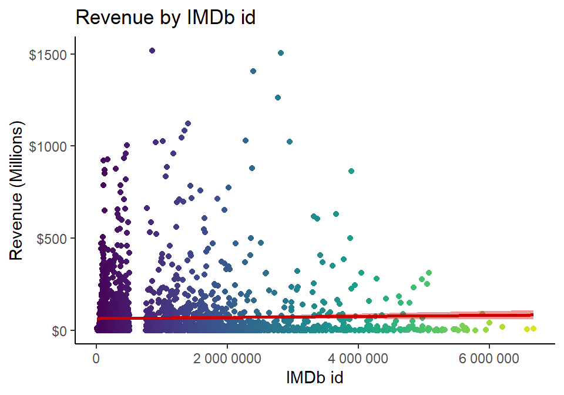

There does not seem to be any trend between IMDb id and revenue. Lets check the correlation to make sure.

```r
cor(full_data$revenue, full_data$imdb_id_2, use = 'complete.obs')
```

```
## [1] 0.02428141
```

This confirms that there is next to no correlation and that it is probably best to not include this variable in our prediction model.

## Language

Lets take a look at the most common original languages for our movies.

```r
full_data[1:3000,] %>%
   group_by(original_language) %>%
   summarise(movie_count = n()) %>%
   arrange(desc(movie_count)) %>%
   filter(!is.na(original_language)) %>%
   head(10)
```

```
## # A tibble: 10 × 2
##    original_language movie_count
##    <chr>                   <int>
##  1 en                       2575
##  2 fr                         78
##  3 ru                         47
##  4 es                         43
##  5 hi                         42
##  6 ja                         37
##  7 it                         24
##  8 cn                         20
##  9 ko                         20
## 10 zh                         19
```

Since the absolute majority of the movies are English, with the second most popular language being French with 78 movies, we will create the variable `language` with levels English versus Non-English.

```r
full_data$language[full_data$original_language=='en'] <- 'English'
full_data$language[is.na(full_data$language)] <- 'Non-English'
```

Now lets plot our new variable to see how it affects revenue.

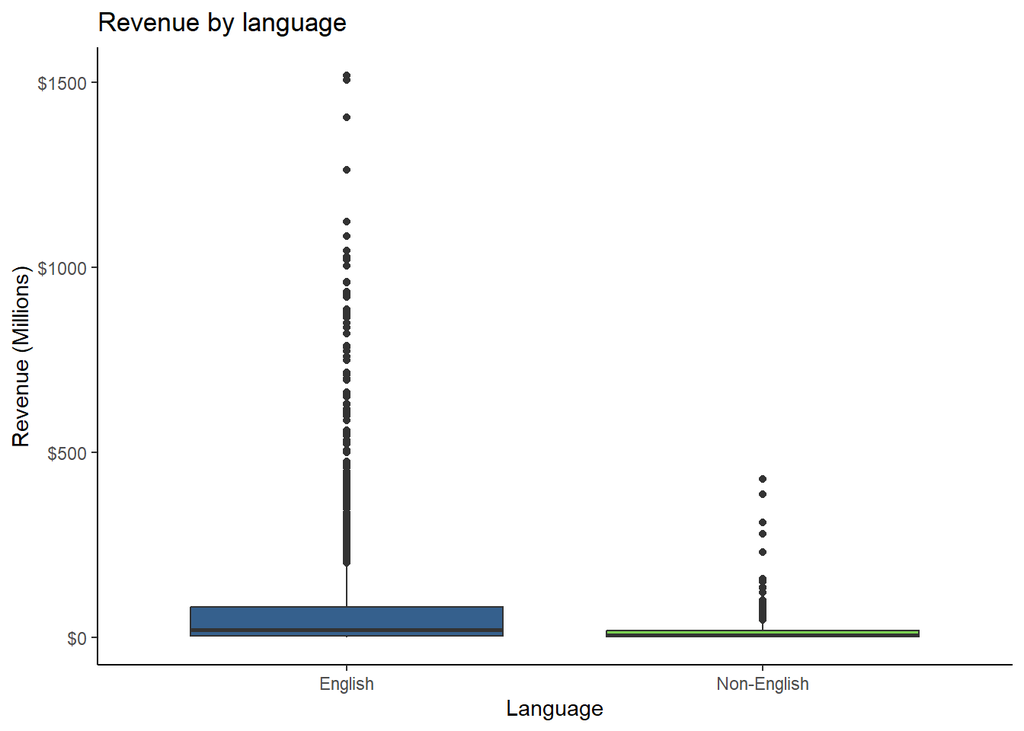

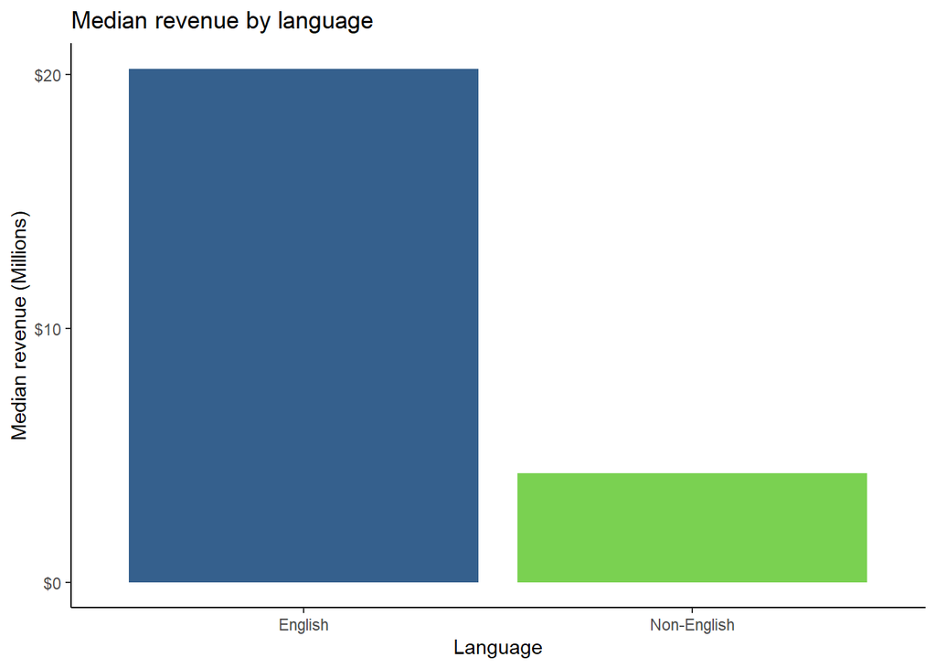

Seems like English-language movies make on average about 5 times the revenue of non-English language movies.

## Year, quarter, month, week, and weekday released

Now we will create 5 new variables: (1) `year_released`, (2) `quarter_released`, (3) `month_released`, (4) `week_released`, and (5) `weekday_released.`

Before creating our variables we will fix missing values for `release_date` so that we do not need to do so for each created variable later.

Lets see which rows have missing values for `release_date` and look up the titles and runtimes.

```r
which(is.na(full_data$release_date))

full_data[3829, c('title', 'runtime')]
```

```
## [1] 3829
##                           title runtime
## 3829 Jails, Hospitals & Hip-Hop      90
```

I found online that the movie was released 3/20/2001 so I’ll add this information.

```r
full_data$release_date[3829] <- '3/20/01'
```

```r
full_data$release_date_mod <- parse_date_time2(full_data$release_date, "mdy",
                                               cutoff_2000 = 20)
```

Create year, quarter, month, week, and weekday released using the LUBRIDATE package.

```r
full_data$year_released <- ymd(full_data$release_date_mod) %>%
   lubridate::year()  # Grab year.

full_data$quarter_released <- ymd(full_data$release_date_mod) %>%
   lubridate::quarter()  # Grab quarter.

full_data$month_released <- ymd(full_data$release_date_mod) %>%
   lubridate::month(label = TRUE, abbr = FALSE)  # Grab month.

full_data$week_released <- ymd(full_data$release_date_mod) %>%
   lubridate::week()  # Grab week.

full_data$weekday_released <- ymd(full_data$release_date_mod) %>%
   lubridate::wday(label = TRUE, abbr = FALSE)  # Grab weekday.
```

Lets graph these variables to see how they affect revenue.

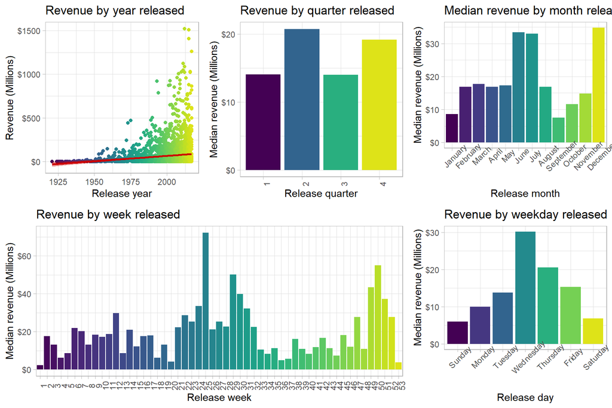

Here we can see that:

- The year plot seems to indicate revenue has been increasing over the years.
- Movies being released in June, July and December seem to be getting higher revenues. This is in line with what one would believe as a lot of blockbuster movies are released during the summer, while a lot of movies that are trying to compete for the Oscars are released in December.
- Movies that are released on Wednesdays seem to be getting somewhat higher revenues as well.

## Tagline presence

Next we will feature engineer a `tagline_presence` variable by simply categorizing whether a movie has a tagline or not.

```r
full_data$tagline_presence[is.na(full_data$tagline)] <- 'No tagline'
full_data$tagline_presence[is.na(full_data$tagline_presence)] <- 'Tagline'
```

Next, lets create a bar plot of `tagline_presence` against `revenue`.

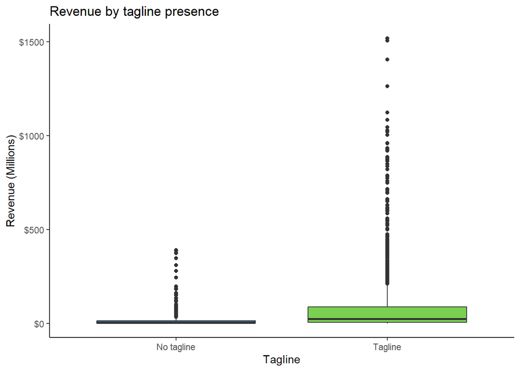

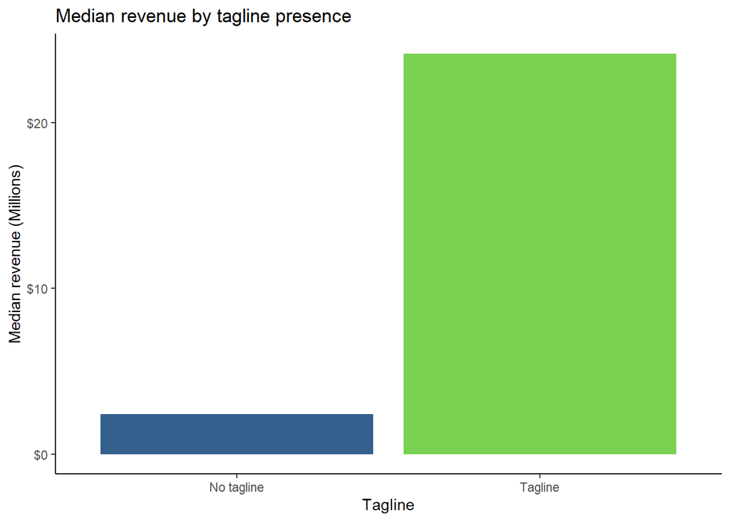

Seems like the median for movies with taglines is about 10 times that of movies without a tagline.

## Homepage presence

Now we will create the `homepage_presence` variable by categorizing if the movies have a homepage or not.

```r
full_data$homepage_presence[is.na(full_data$homepage)] <- 'No homepage'
full_data$homepage_presence[is.na(full_data$homepage_presence)] <- 'Homepage'
```

Now lets plot this new feature.

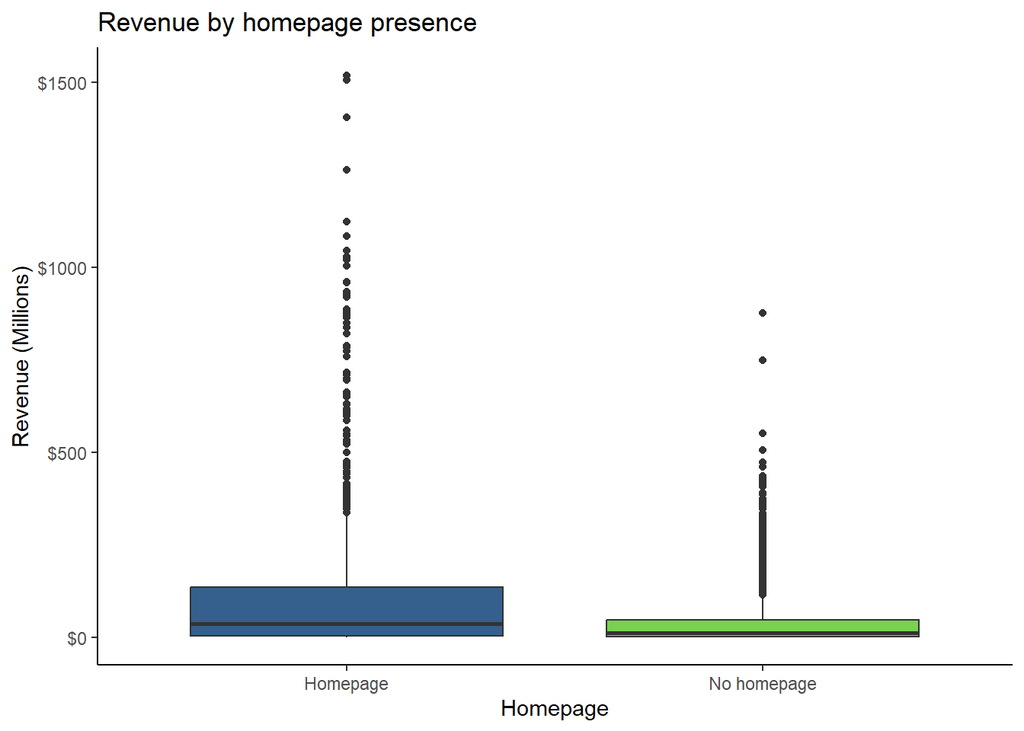

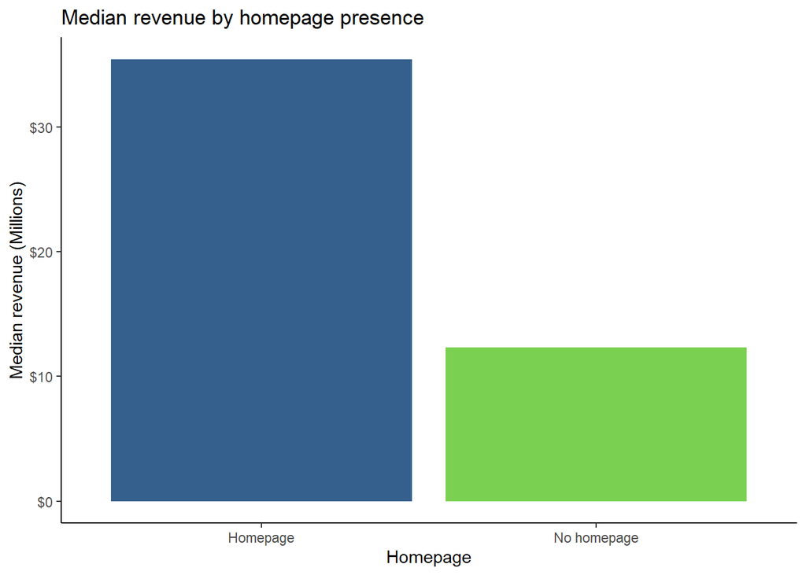

Movies with homepages seem to be making on average 3 times as much as movies without a homepage.

## Gender of cast & crew

We will now create new variables to see how gender of cast and crew affect revenue.

```r
# Total cast count and by gender
full_data$number_of_cast <- str_count(full_data$cast, 'name')
full_data$female_cast <- str_count(full_data$cast, ('gender\'\\:\\s1'))
full_data$male_cast <- str_count(full_data$cast, ('gender\'\\:\\s2'))
full_data$unspecified_cast <- str_count(full_data$cast, ('gender\'\\:\\s0'))

# Total crew count and by gender
full_data$number_of_crew <- str_count(full_data$crew, 'name')
full_data$female_crew <- str_count(full_data$crew, ('gender\'\\:\\s1'))
full_data$male_crew <- str_count(full_data$crew, ('gender\'\\:\\s2'))
full_data$unspecified_crew <- str_count(full_data$crew, ('gender\'\\:\\s0'))
```

Lets plot this.

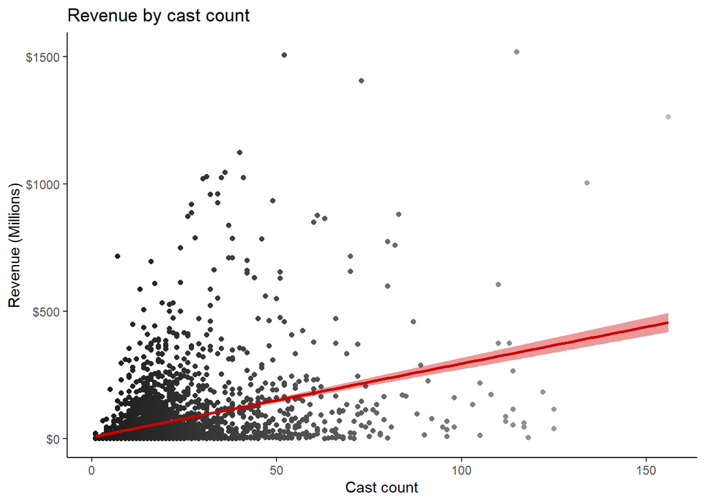

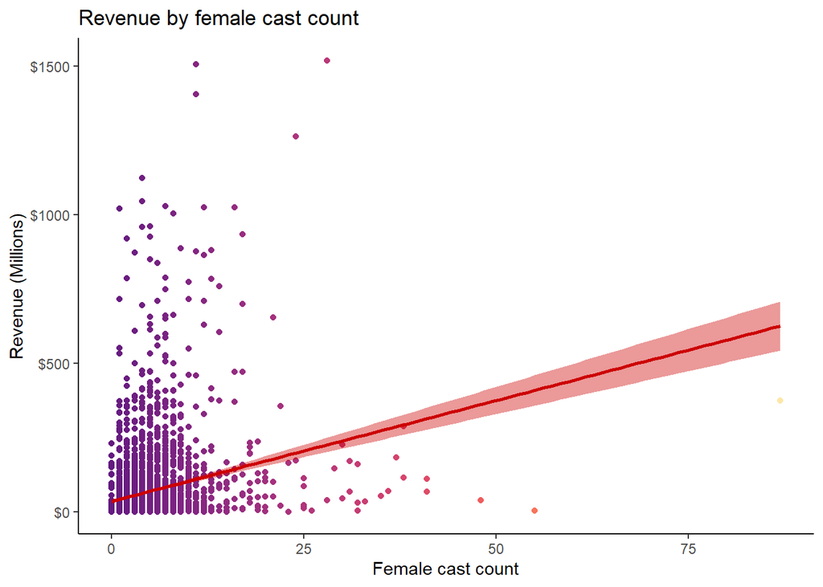

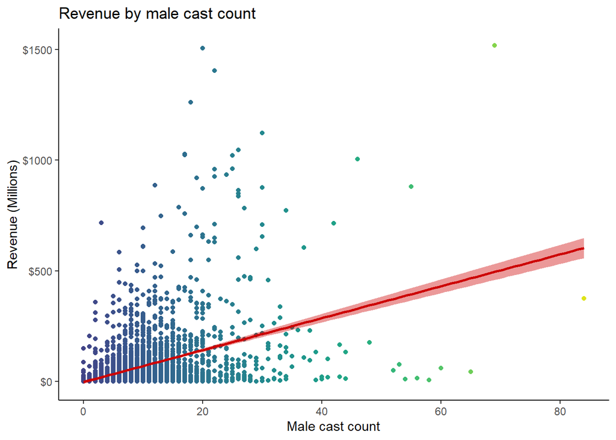

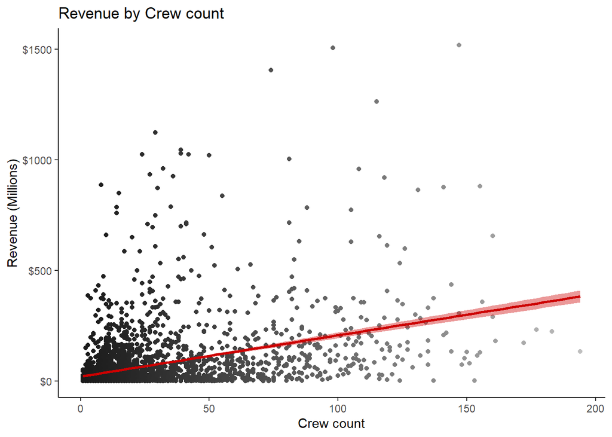

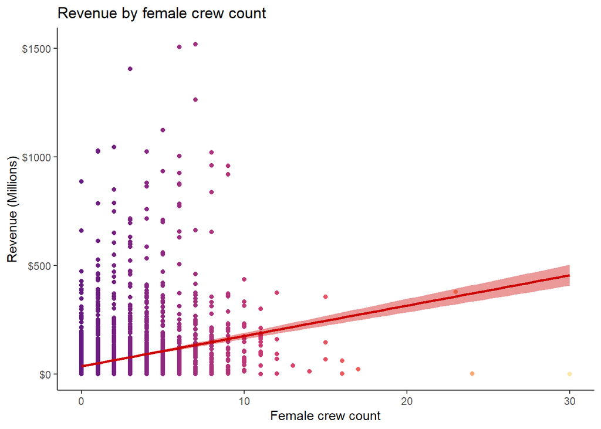

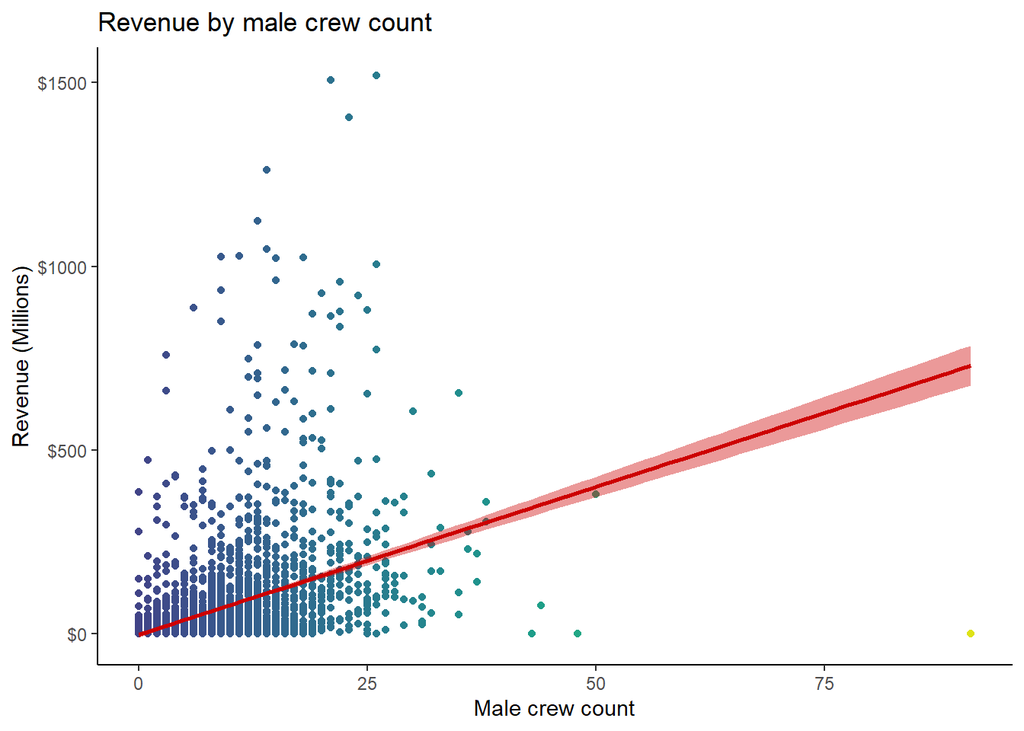

Here we can see the distribution in revenue by gender for cast and crew. There seems to be a quite clear trend that the more cast and crew the movie has, the higher the revenue.

## Number of…

Now we will create multiple new features by extracting the number of occurrences of certain variables within a string. We will extract the number of: (1) **genres**, (2) **production companies**, (3) **production countries**, (4) **spoken languages**, and (5) **keywords**. We will do this by counting the occurrence of ‘name’ in each string.

```r
full_data$number_of_genres <- str_count(full_data$genres, 'name')
full_data$number_of_prod_companies <- str_count(full_data$production_companies, 'name')
full_data$number_of_prod_countries <- str_count(full_data$production_countries, 'name')
full_data$number_of_spoken_languages <- str_count(full_data$spoken_languages, 'name')
full_data$number_of_keywords <- str_count(full_data$Keywords, 'name')
```

Now lets plot these variables.

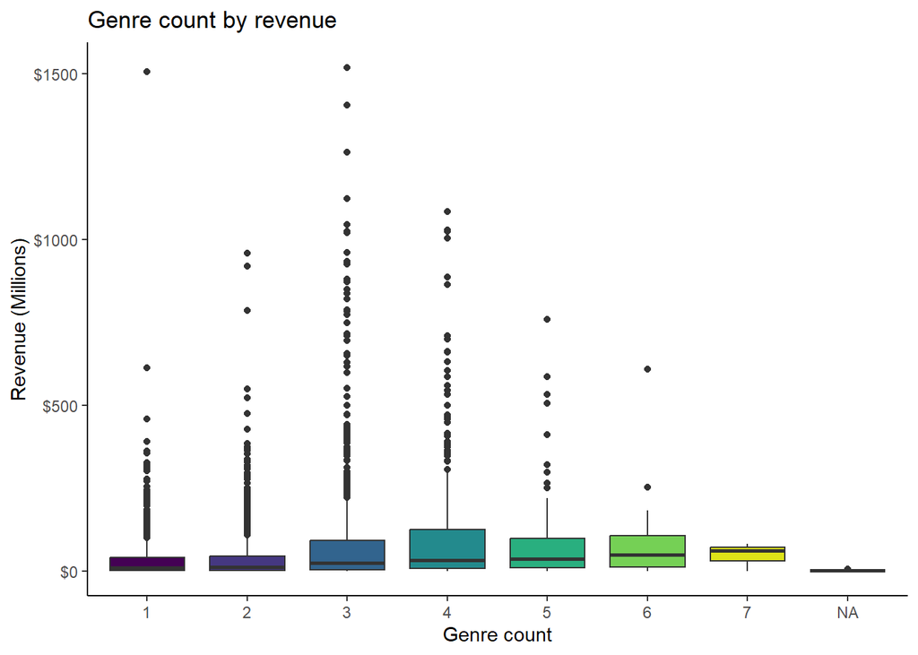

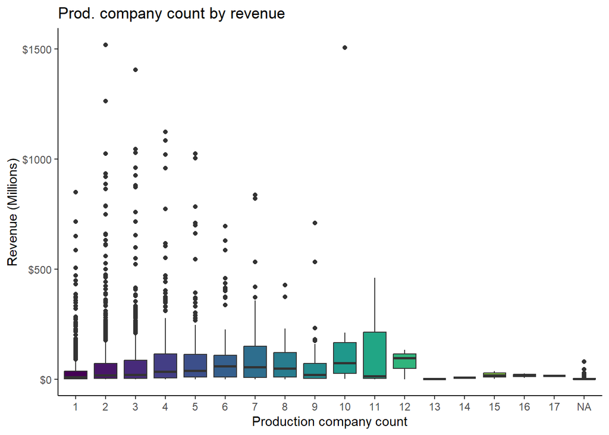

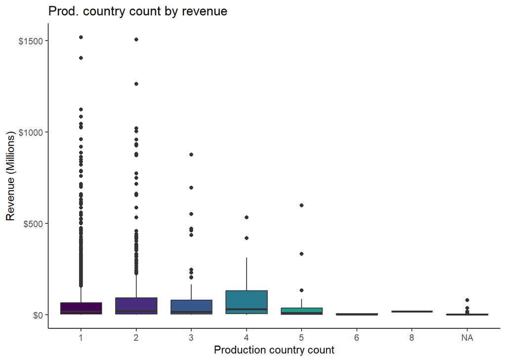